# R and Bioconductor Introduction

Mark Dunning

Last modified: 24 Aug 2017

# About R

If you haven’t done so already, you can check out our [R crash course](https://bioinformatics-core-shared-training.github.io/r-crash-course/) for an overview of wh R is great and some of the basic syntax. Here are some great examples of people that have used R to do cool stuff with data

- [Facebook](http://blog.revolutionanalytics.com/2010/12/analysis-of-facebook-status-updates.html),
- [google](http://blog.revolutionanalytics.com/2009/05/google-using-r-to-analyze-effectiveness-of-tv-ads.html),
- [Microsoft](http://blog.revolutionanalytics.com/2014/05/microsoft-uses-r-for-xbox-matchmaking.html) (who recently [invested](http://blogs.microsoft.com/blog/2015/01/23/microsoft-acquire-revolution-analytics-help-customers-find-big-data-value-advanced-statistical-analysis/) in a commerical provider of R)
- The [New York Times](http://blog.revolutionanalytics.com/2011/03/how-the-new-york-times-uses-r-for-data-visualization.html).
- [Buzzfeed](http://blog.revolutionanalytics.com/2015/12/buzzfeed-uses-r-for-data-journalism.html) use R for some of their serious articles and have made the code [publically available](https://buzzfeednews.github.io/2016-04-federal-surveillance-planes/analysis.html)
- The [New Zealand Tourist Board](https://mbienz.shinyapps.io/tourism_dashboard_prod/) have R running in the background of their website
- [Airbnb](https://medium.com/airbnb-engineering/using-r-packages-and-education-to-scale-data-science-at-airbnb-906faa58e12d)
- [The BBC](https://github.com/BBC-Data-Unit/music-festivals) makes code available for some of their stories (e.g. gender bias in music festivals)

R’s role in promoting reproducible research cannot be overstated.

Two Biostatiscians (later termed ‘*Forensic Bioinformaticians*’) from M.D. Anderson used R extensively during their re-analysis and investigation of a Clinical Prognostication paper from Duke. The subsequent [scandal](https://www.youtube.com/watch?v=W5sZTNPMQRM) put Reproducible Research at the forefront of everyone’s mind.

Keith Baggerly’s talk on the subject is highly-recommended.

[video not shown]

## About the practicals for this workshop

- The traditional way to enter R commands is via the Terminal, or using the console in RStudio (bottom-left panel when RStudio opens for first time).
- However, for this course we will use a relatively new feature called *R-notebooks*.
- An R-notebook mixes plain text with R code

Markdown is a very simple way of writing a template to produce a pdf, HTML or word document. The compiled version of this document is available online and is more convenient to browse [here](https://bioinformatics-core-shared-training.github.io/cruk-autumn-school-2017/Day1/bioc-intro.nb.html).

- “chunks” of R code can be added using the *insert* option from the toolbar, or the CTRL + ALT + I shortcut
- Each line of R can be executed by clicking on the line and pressing CTRL and ENTER
- Or you can press the green triangle on the right-hand side to run everything in the chunk
- Try this now!
- The code might have different options which dictate how the output is displayed in the compiled document (e.g. HTML)
  - e.g. you might see `EVAL = FALSE` or `echo = FALSE`
  - you don’t have to worry about this if stepping through the markdown interactively

```r
print("Hello World")
```

```
[1] "Hello World"
```

*This will be displayed in italic*

**This will be displayed in bold**

- this
- is
- a
- list
  - this is a *sub-list*

You can also add hyperlinks, images and tables. More help is available through RStudio **Help -> Markdown Quick Reference**

# About the Bioconductor project

Established in 2001 as a means of distributing tools for the analysis and comprehension of high-throughput genomic data in R. Initially focused on microarrays, but now has many tools for NGS data

- primary processing of NGS data nearly-always done in other languages
  - R is extensively-used for visualisation and interpretation once data are in manageable form

On the Bioconductor website,. you will find

- Installation instructions
- [Course Materials](http://bioconductor.org/help/course-materials/)
- [Support forum](https://support.bioconductor.org/)
  - a means of communicating with developers and power-users
- [Example datasets](http://bioconductor.org/packages/release/BiocViews.html#___ExperimentData)
- [Annotation Resources](http://bioconductor.org/packages/release/BiocViews.html#___AnnotationData)
- Conferences
  - upcoming conference in Cambridge - [December 2017](https://bioconductor.github.io/EuroBioc2017/)

For this session, we will introduce the Bioconductor project as a means of analysing high-throughput data

## Installing a package

All Bioconductor software packages are listed under

- bioconductor.org -> Install -> Packages -> Analysis *software* packages
- e.g. [edgeR landing page](http://bioconductor.org/packages/release/bioc/html/edgeR.html)
- installation instructions are given, which involves running the `biocLite` command
- this will install any additional dependancies
- you only need to run this procedure once for each version of R

```r
source("http://www.bioconductor.org/biocLite.R")
biocLite("edgeR")
```

Once installed, a Bioconductor package can be loaded in the usual way with the `library` function. All packages are required to have a *vignette* which gives detailed instructions on how to use the package and the workflow of commands. Some packages such as `edgeR` have very comprehensive *user guides* with lots of use-cases.

```r
library(edgeR)
vignette("edgeR")
edgeRUsersGuide()
```

Package documentation can also be accessed via the *Help* tab in RStudio.

## Structures for data analysis

Complex data structures are used in Bioconductor to represent high-throughput data, but we often have simple functions that we can use to access the data. We will use some example data available through Bioconductor to demonstrate how high-throughput data can be represented, and also to review some basic concepts in data manipulation in R.

- the data are from a microarray experiment. We will be concentrating on more-modern techniques in this class, but most of the R techniques required will be the same.
- [experimental data](http://bioconductor.org/packages/release/BiocViews.html#___ExperimentData) packages are available through Bioconductor, and can be installed in the way we just described
- the package should already be installed on your computer, so you won’t need to run this.

```r
## No need to run this - for reference only!
##

biocLite("breastCancerVDX")
```

To make the dataset accessible in R, we need to load the library and use the `data` function.

- typing the name of the object provides a summary

```r
library(breastCancerVDX)
data(vdx)
vdx
```

```
ExpressionSet (storageMode: lockedEnvironment)
assayData: 22283 features, 344 samples
  element names: exprs
protocolData: none
phenoData
  sampleNames: VDX_3 VDX_5 ... VDX_2038 (344 total)
  varLabels: samplename dataset ... e.os (21 total)
  varMetadata: labelDescription
featureData
  featureNames: 1007_s_at 1053_at ... AFFX-TrpnX-M_at (22283 total)
  fvarLabels: probe Gene.title ... GO.Component.1 (22 total)
  fvarMetadata: labelDescription
experimentData: use 'experimentData(object)'
  pubMedIds: 17420468
Annotation: hgu133a
```

## Accessing expression values

The expression values can be obtained by the `exprs` function:-

- the data are stored in a `matrix` in R
  - it is a good idea to check the dimensions using `dim`, `ncol`, `nrow` etc

```r
eValues <- exprs(vdx)
class(eValues)
```

```
[1] "matrix"
```

- the rownames are the manufacturer-assigned ID for a particular probe
- the column names are the identifiers for each patient in the study
- each entry is a *normalised* log$_2$ intensity value for a particular gene in a given sample
- subsetting a matrix is done using the `[row, column]` notation
  - the function `c` is used to make a one-dimensional *vector*
  - the shortcut `:` can used to stand for a sequence of consecutive numbers

```r
eValues[c(1,2,3),c(1,2,3,4)]
```

```
              VDX_3     VDX_5     VDX_6     VDX_7
1007_s_at 11.965135 11.798593 11.777625 11.538577
1053_at    7.895424  7.885696  7.949535  7.481396
117_at     8.259272  7.052025  8.225930  8.382408
```

```r
eValues[1:3,1:4]
```

```
              VDX_3     VDX_5     VDX_6     VDX_7
1007_s_at 11.965135 11.798593 11.777625 11.538577
1053_at    7.895424  7.885696  7.949535  7.481396
117_at     8.259272  7.052025  8.225930  8.382408
```

- we can also omit certain rows or columns from the output by prefixing the indices with a `-`

```r
eValues[1:3,-(1:4)]
```

## Simple visualisations

The most basic plotting function in R is `plot`

- using the `plot` function with a vector will plot the values of that vector against the index
  - what do you think is displayed in the plot below?

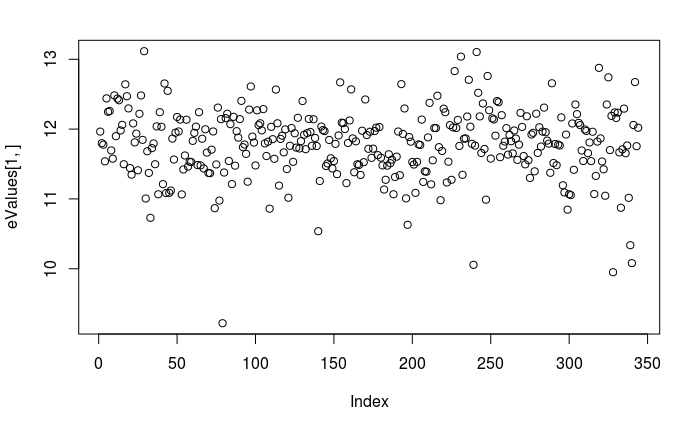

The *boxplot* is a common plotting tool in R to compare distributions

- one possible use is to compare the values in a vector with respect to a given factor
- as we don’t know the clinical variables in our dataset yet (to come later), we have to make something up

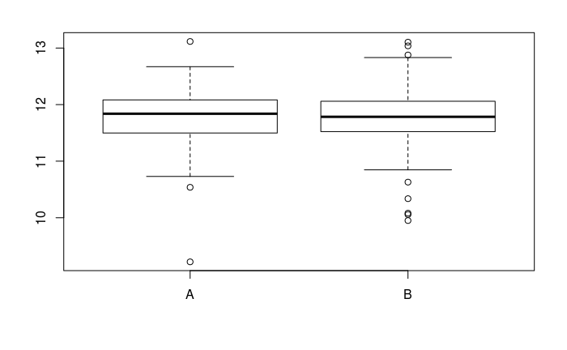

A boxplot can also accept a matrix of data frame as an argument

- what do you think the following plot shows?

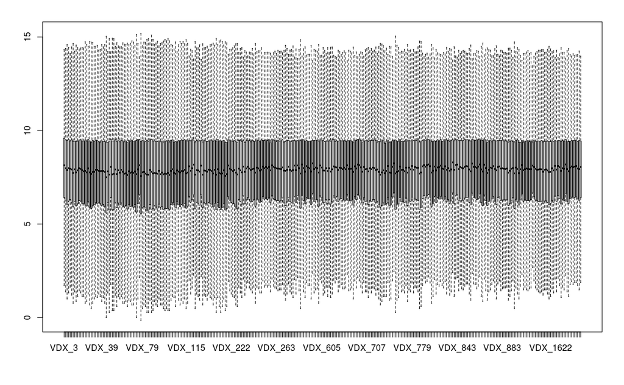

## Accessing patient data

The *metadata*, or phenotypic data, for the samples is retrieved using the `pData` function.

Indivdual columns can be accessed using the `$` notation.

- *auto-complete* is available in RStudio; once you type the `$`it should give you a list of possible options.
- the data are returned as a *vector*, which can be fed-into other standard plotting and analysis functions

## Exercise

- what type of R object is used to store the metadata
- why is this different to the object used for the expression values?
- use the square bracket notation `[]` to print
  - the first 10 rows of the metadata object, first five columns
  - last 10 rows of the metadata object, columns 7 to 9
- visualise the distribution of the patients ages using a histogram
- Calculate the average age of patients in the study with the `mean` function
  - what do you notice about the result?
  - can you change the arguments to mean to get a more meaningful result

```r
metadata <- pData(vdx)
metadata
```

|  | samplename | dataset | series | id | filename | size | age | er | grade | pgr | her2 | brca.mutation | e.dmfs | t.dmfs | node | t.rfs | e.rfs | treatment | tissue | t.os | e.os |
| --- | --- | --- | --- | --- | --- | --- | --- | --- | --- | --- | --- | --- | --- | --- | --- | --- | --- | --- | --- | --- | --- |
| VDX_3 | VDX_3 | VDX | VDX | 3 | GSM36793.CEL.gz | NA | 36 | 0 | NA | NA | NA | NA | 0 | 3072 | 0 | NA | NA | 0 | 1 | NA | NA |
| VDX_5 | VDX_5 | VDX | VDX | 5 | GSM36796.CEL.gz | NA | 47 | 1 | 3 | NA | NA | NA | 0 | 3589 | 0 | NA | NA | 0 | 1 | NA | NA |
| VDX_6 | VDX_6 | VDX | VDX | 6 | GSM36797.CEL.gz | NA | 44 | 0 | 3 | NA | NA | NA | 1 | 274 | 0 | NA | NA | 0 | 1 | NA | NA |
| VDX_7 | VDX_7 | VDX | VDX | 7 | GSM36798.CEL.gz | NA | 41 | 0 | 3 | NA | NA | NA | 0 | 3224 | 0 | NA | NA | 0 | 1 | NA | NA |
| VDX_8 | VDX_8 | VDX | VDX | 8 | GSM36800.CEL.gz | NA | 70 | 0 | NA | NA | NA | NA | 1 | 1125 | 0 | NA | NA | 0 | 1 | NA | NA |
| VDX_9 | VDX_9 | VDX | VDX | 9 | GSM36801.CEL.gz | NA | 62 | 1 | 3 | NA | NA | NA | 0 | 3802 | 0 | NA | NA | 0 | 1 | NA | NA |
| VDX_11 | VDX_11 | VDX | VDX | 11 | GSM36834.CEL.gz | NA | 69 | 1 | 3 | NA | NA | NA | 0 | 3315 | 0 | NA | NA | 0 | 1 | NA | NA |
| VDX_14 | VDX_14 | VDX | VDX | 14 | GSM36835.CEL.gz | NA | 68 | 0 | 3 | NA | NA | NA | 1 | 426 | 0 | NA | NA | 0 | 1 | NA | NA |
| VDX_15 | VDX_15 | VDX | VDX | 15 | GSM36836.CEL.gz | NA | 44 | 1 | 3 | NA | NA | NA | 0 | 3011 | 0 | NA | NA | 0 | 1 | NA | NA |
| VDX_17 | VDX_17 | VDX | VDX | 17 | GSM36837.CEL.gz | NA | 51 | 1 | 3 | NA | NA | NA | 0 | 4167 | 0 | NA | NA | 0 | 1 | NA | NA |

[output cut: 334 more lines]

So far we have been able to print out a subset of our data by specifying a set of numeric indices. Lets say we’re interested in high-grade tumours, in which case we might not know in advance which rows / columns these correspond to

- `==` `>`, `<`, `!=` can used to make a *logical comparison*
- result is a `TRUE` or `FALSE` indicating whether each entry satisfies the test condition, or not.
  - however, if a particular entry in the vector is `NA` the resulting logical vector will have `NA` at the same positions

```r
metadata$grade == 3
metadata$age > 70
```

Such a logical vector can then be used for subsetting

- `which` can be used to make sure there are no `NA` values in the logical vectors
  - it gives the numeric indices that correspond to `TRUE`
- here, we don’t specify any column indices inside the `[]`
  - R will print all the columns
  - however, don’t forget the ,!

```r
metadata[which(metadata$grade == 3),]
```

Can use same expression to subset the columns of the expression matrix

- why can we do this? Because the *columns* of the expression matrix are in the same order as the *rows* of the metadata
  - don’t believe me? see below…
- this isn’t a coincidence. the data have been carefully curated to ensure that this is the case
- data stored in online repositories are often organised in this way

```r
colnames(eValues)
rownames(metadata)
colnames(eValues) == rownames(metadata)
all(colnames(eValues) == rownames(metadata))
```

- we can subset the expression data according to our clinical data, and save the result to a file

```r
highGradeExpression <- eValues[,metadata$grade==3]
write.csv(highGradeExpression, file="highGradeTumours.csv")
```

Previously, we used a boxplot to visualise the expression levels of all genes in a given sample to look for trends across the dataset. Another use for a boxplot is to visualise the expression level of a particular gene with respect to the sample metadata

- we can extract the column of interest with a `$` and use the *formula* syntax
- R will be clever and convert the factor into a `factor` type if required

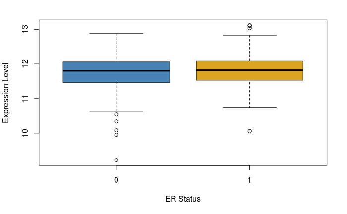

```r
fac <- metadata$er
boxplot(eValues[1,] ~ fac,
        xlab="ER Status",
        ylab="Expression Level",
        col=c("steelblue","goldenrod"))
```

Performing a test to assess significance follows similar syntax

- `t.test` is the generic function to perform a t-test, and can be adapted to different circumstances
  - e.g. if our data are paired, or not
  - see the help for `t.test` for more details
- for now, we will skip over testing assumptions on the data such as requiring a *normal* (Gaussian) distribtion

```r
t.test(eValues[1,]~fac)
```

```
    Welch Two Sample t-test

data:  eValues[1, ] by fac
t = -1.7476, df = 244.15, p-value = 0.08179
alternative hypothesis: true difference in means is not equal to 0
95 percent confidence interval:
 -0.2101311  0.0125555
sample estimates:
mean in group 0 mean in group 1
       11.72515        11.82394
```

## Accessing feature (gene) information

We could be lucky, and the first row in the expression matrix could be our favourite gene of interest! However, this is unlikely to be the case and we will have to figure out which row we want to plot

```r
features <- fData(vdx)
class(features)
```

```
[1] "data.frame"
```

```r
features[1:10,]
```

|  | probe | Gene.title | Gene.symbol | Gene.ID | EntrezGene.ID | UniGene.title | UniGene.symbol | UniGene.ID | Nucleotide.Title | GI | GenBank.Accession | Platform_CLONEID | Platform_ORF | Platform_SPOTID | Chromosome.location | Chromosome.annotation | GO.Function | GO.Process | GO.Component | GO.Function.1 | GO.Process.1 | GO.Component.1 |
| --- | --- | --- | --- | --- | --- | --- | --- | --- | --- | --- | --- | --- | --- | --- | --- | --- | --- | --- | --- | --- | --- | --- |
| 1007_s_at | 1007_s_at | discoidin domain receptor tyrosine kinase 1 | DDR1 | 780 | 780 | NA | NA | NA | Human receptor tyrosine kinase DDR gene, complete cds | 1753221 | U48705 | NA | NA | NA | 6p21.3 | Chromosome 6, NC_000006.11 (30851861..30867933) | ATP binding///nucleotide binding///protein binding///receptor activity///transferase activity///transmembrane receptor protein tyrosine kinase activity | cell adhesion///protein amino acid phosphorylation///transmembrane receptor protein tyrosine kinase signaling pathway | extracellular region///integral to plasma membrane///membrane | GO:0005524///GO:0000166///GO:0005515///GO:0004872///GO:0016740///GO:0004714 | GO:0007155///GO:0006468///GO:0007169 | GO:0005576///GO:0005887///GO:0016020 |
| 1053_at | 1053_at | replication factor C (activator 1) 2, 40kDa | RFC2 | 5982 | 5982 | NA | NA | NA | Human replication factor C, 40-kDa subunit (A1) mRNA, complete cds | 1590810 | M87338 | NA | NA | NA | 7q11.23 | Chromosome 7, NC_000007.13 (73645832..73668738, complement) | ATP binding///DNA clamp loader activity///nucleoside-triphosphatase activity///nucleotide binding///protein binding | DNA replication///nucleotide-excision repair, DNA gap filling | DNA replication factor C complex///nucleoplasm///nucleus | GO:0005524///GO:0003689///GO:0017111///GO:0000166///GO:0005515 | GO:0006260///GO:0006297 | GO:0005663///GO:0005654///GO:0005634 |
| 117_at | 117_at | heat shock 70kDa protein 6 (HSP70B') | HSPA6 | 3310 | 3310 | NA | NA | NA | Human heat-shock protein HSP70B' gene | 35221 | X51757 | NA | NA | NA | 1q23 | Chromosome 1, NC_000001.10 (161494036..161496687) | ATP binding///nucleotide binding | response to unfolded protein | NA | GO:0005524///GO:0000166 | GO:0006986 | NA |
| 121_at | 121_at | paired box 8 | PAX8 | 7849 | 7849 | NA | NA | NA | H.sapiens Pax8 mRNA | 38425 | X69699 | NA | NA | NA | 2q12-q14 | Chromosome 2, NC_000002.11 (113973574..114036498, complement) | DNA binding///protein binding///sequence-specific DNA binding///thyroid-stimulating hormone receptor activity///transcription activator activity///transcription activator activity///transcription fact… | anatomical structure morphogenesis///cell differentiation///metanephros development///multicellular organismal development///positive regulation of transcription from RNA polymerase II promoter///posi… | nucleoplasm///nucleus | GO:0003677///GO:0005515///GO:0043565///GO:0004996///GO:0016563///GO:0016563///GO:0003700 | GO:0009653///GO:0030154///GO:0001656///GO:0007275///GO:0045944///GO:0045893///GO:0045893///GO:0030878 | GO:0005654///GO:0005634 |
| 1255_g_at | 1255_g_at | guanylate cyclase activator 1A (retina) | GUCA1A | 2978 | 2978 | NA | NA | NA | Homo sapiens guanylate cyclase activating protein (GCAP) gene exons 1-4, complete cds | 623404 | L36861 | NA | NA | NA | 6p21.1 | Chromosome 6, NC_000006.11 (42123144..42147794) | calcium ion binding///calcium sensitive guanylate cyclase activator activity | response to stimulus///signal transduction///visual perception | membrane | GO:0005509///GO:0008048 | GO:0050896///GO:0007165///GO:0007601 | GO:0016020 |
| 1294_at | 1294_at | ubiquitin-like modifier activating enzyme 7 | UBA7 | 7318 | 7318 | NA | NA | NA | Homo sapiens ubiquitin-activating enzyme E1 related protein mRNA, complete cds | 520832 | L13852 | NA | NA | NA | 3p21 | Chromosome 3, NC_000003.11 (49842638..49851391, complement) | ATP binding///ISG15 activating enzyme activity///ligase activity///nucleotide binding | ISG15-protein conjugation///metabolic process///modification-dependent protein catabolic process///protein modification process | NA | GO:0005524///GO:0019782///GO:0016874///GO:0000166 | GO:0032020///GO:0008152///GO:0019941///GO:0006464 | NA |
| 1316_at | 1316_at | thyroid hormone receptor, alpha (erythroblastic leukemia viral (v-erb-a) oncogene homolog, avian) | THRA | 7067 | 7067 | NA | NA | NA | Homo sapiens mRNA for thyroid hormone receptor alpha 1 THRA1, (c-erbA-1 gene) | 29878 | X55005 | NA | NA | NA | 17q11.2 | Chromosome 17, NC_000017.10 (38219063..38250120) | TATA-binding protein binding///metal ion binding///promoter binding///protein binding///protein domain specific binding///protein heterodimerization activity///protein homodimerization activity///ster… | adrenal gland development///brain development///cartilage condensation///cytoplasmic sequestering of transcription factor///digestive tract development///embryonic organ development///erythrocyte diff… | cytoplasm///cytosol///mitochondrion///nucleus | GO:0017025///GO:0046872///GO:0010843///GO:0005515///GO:0019904///GO:0046982///GO:0042803///GO:0003707///GO:0002153///GO:0070324///GO:0070324///GO:0004887///GO:0016563///GO:0003700///GO:0008134///GO:00… | GO:0030325///GO:0007420///GO:0001502///GO:0042994///GO:0048565///GO:0048568///GO:0030218///GO:0008050///GO:0009755///GO:0001822///GO:0007611///GO:0001889///GO:0030324///GO:0017055///GO:0043433///GO:00… | GO:0005737///GO:0005829///GO:0005739///GO:0005634 |
| 1320_at | 1320_at | protein tyrosine phosphatase, non-receptor type 21 | PTPN21 | 11099 | 11099 | NA | NA | NA | H.sapiens mRNA for protein-tyrosine-phosphatase D1 | 532055 | X79510 | NA | NA | NA | 14q31.3 | Chromosome 14, NC_000014.8 (88932122..89021123, complement) | binding///hydrolase activity///protein tyrosine phosphatase activity | protein amino acid dephosphorylation | cytoplasm///cytoskeleton | GO:0005488///GO:0016787///GO:0004725 | GO:0006470 | GO:0005737///GO:0005856 |
| 1405_i_at | 1405_i_at | chemokine (C-C motif) ligand 5 | CCL5 | 6352 | 6352 | NA | NA | NA | Human T cell-specific protein (RANTES) mRNA, complete cds | 339420 | M21121 | NA | NA | NA | 17q11.2-q12 | Chromosome 17, NC_000017.10 (34198495..34207377, complement) | chemoattractant activity///chemokine activity///receptor binding///signal transducer activity | aging///cell adhesion///cell-cell signaling///cellular calcium ion homeostasis///cellular component movement///cellular defense response///chemotaxis///chronic inflammatory response///exocytosis///imm… | cytoplasm///extracellular region///extracellular space///soluble fraction | GO:0042056///GO:0008009///GO:0005102///GO:0004871 | GO:0007568///GO:0007155///GO:0007267///GO:0006874///GO:0006928///GO:0006968///GO:0006935///GO:0002544///GO:0006887///GO:0006955///GO:0006954///GO:0048247///GO:0045071///GO:0031622///GO:0045672///GO:00… | GO:0005737///GO:0005576///GO:0005615///GO:0005625 |
| 1431_at | 1431_at | cytochrome P450, family 2, subfamily E, polypeptide 1 | CYP2E1 | 1571 | 1571 | NA | NA | NA | Human cytochrome P450IIE1 (ethanol-inducible) gene, complete cds | 181355 | J02843 | NA | NA | NA | 10q24.3-qter | Chromosome 10, NC_000010.10 (135340867..135352620) | electron carrier activity///enzyme binding///heme binding///metal ion binding///monooxygenase activity///oxidoreductase activity///oxidoreductase activity, acting on paired donors, with incorporation … | drug metabolic process///drug metabolic process///heterocycle metabolic process///monoterpenoid metabolic process///oxidation reduction///response to ethanol///response to organic nitrogen///steroid m… | Golgi membrane///endoplasmic reticulum///endoplasmic reticulum membrane///intrinsic to endoplasmic reticulum membrane///membrane///microsome///mitochondrion | GO:0009055///GO:0019899///GO:0020037///GO:0046872///GO:0004497///GO:0016491///GO:0016709///GO:0016712///GO:0019825 | GO:0017144///GO:0017144///GO:0046483///GO:0016098///GO:0055114///GO:0045471///GO:0010243///GO:0008202 | GO:0000139///GO:0005783///GO:0005789///GO:0031227///GO:0016020///GO:0005792///GO:0005739 |

As we know, gene symbols (more-common gene names) can be accessed using the `$` syntax; returning a vector

```r
features$Gene.symbol
```

We could inspect the data frame manually (e.g. using `View(features)`) and identfy the row number corresponding to our gene of interest. However, as aspiring R programmers, there is a better way

- `==` to test for exact matching
- `match` will return the *index* of the first match
- `grep` can be used for partial matches

```r
grep("BRCA",features$Gene.symbol)
```

```
[1]  4058  7869 11245 14103
```